# Discussion 7 - solution

# Preliminaries

- This file should be in `STAT240/discussion/ds07` and the script `ggprob.R` should be in `STAT240/scripts` on your local computer.
- This assignment should be completed in your **assigned Canvas groups**. Only one person has to submit on behalf of the group. You may submit whatever you have at the end of discussion section for full credit.

# Present Group Members

Please **write the names of the present group members** here.

> Present Group Members:

> Absent Group Members:

# Problem 1

For each scenario, explain why the random variable will or will not have a binomial distribution. If not, cite the specific BINS assumption(s) that are not met.

1. A bucket contains 10 colored tokens with five that are red and five that are blue. Four tokens are drawn at random from the bucket one at a time, but without replacing the tokens drawn. $X_1$ is the number of red tokens selected.

> Not a binomial distribution. Since the trials are not independent.
2. A fair coin is tossed repeatedly until the tenth head is tossed. $X_2$ is the number of tails tossed prior to the tenth head.

> Not a binomial distribution. Since the number of trials is not fixed.
3. Four buckets each contain a total of five tokens each, some red and some blue. The number of red tokens in the buckets are 1, 2, 3, and 4 with blue tokens making up the remainder. One token is drawn at random from each bucket. $X_3$ is the total number of red tokens drawn.

> Not a binomial distribution. The probabilities of drawing a red token are not the same for each trial

# Problem 2

For $X \sim \text{Binomial}(15,0.2)$

- Part a: Calculate the mean, variance and standard deviation of $X$.

```r
# Write your code here
```

Solution:

```r
n = 15
p = 0.2
mu = n*p
sigma = sqrt(n*p*(1-p))
```

- Part b: Calculate the probability of an outcome greater than or equal to 4. List all the ways you can find this probability.

```r
# Write your code here
```

Solution:

```r
1 - pbinom(3, 15, 0.2)
```

```
## [1] 0.3518379
```

```r
pbinom(3, 15, 0.2, lower.tail = FALSE)
```

```
## [1] 0.3518379
```

```r
sum(dbinom(4:15, 15, 0.2))
```

```
## [1] 0.3518379
```

# Problem 3

Event A: $X_1 < X_2$  
Event B: $X_1 = \mu$  
Event C: $\mu - \sigma < X_2 < \mu + \sigma$  
Event D: $X_1 > 1.5$ AND $X_2 > 1.5$

Event A:Due to symmetricity of the Normal distribution and both of the variables having the same mean. Thus $P(X_1<X_2)=0.5$.

Event B: Since $X_1$ is a continuous variable, probability at a point is 0.

```r
# Event C

pnorm(1, 0, 1) - pnorm(-1, 0, 1)
```

```
## [1] 0.6826895
```

```r
# Event D

pnorm(1.5, 0, 1, lower.tail = FALSE)^2
```

```
## [1] 0.004463202
```

> Thus the probability of the events is in the order, C > A > D > B

# Problem 4

Create a data frame with columns `n`, `p`, `x`, `mu`, and `prob` where:

- `n` varies from 2 to 100 by twos (so each `n` value is even);
- `p` equals 0.5;
- `x` is $n/2$;
- `mu` is the mean of the distribution;
- `prob` is $P(X = x)$

Show the first few rows using `head()`.

```r
prob5 = tibble(
  n = seq(2, 100, by = 2),
  p = 0.5,
  x = n/2,
  mu = n*p,
  sigma = sqrt(n*p*(1-p)),
  prob = dbinom(x, n, p))

head(prob5)
```

```
## # A tibble: 6 × 6
##       n     p     x    mu sigma  prob
##   <dbl> <dbl> <dbl> <dbl> <dbl> <dbl>
## 1     2   0.5     1     1 0.707 0.5
## 2     4   0.5     2     2 1     0.375
## 3     6   0.5     3     3 1.22  0.312
## 4     8   0.5     4     4 1.41  0.273
## 5    10   0.5     5     5 1.58  0.246
## 6    12   0.5     6     6 1.73  0.226
```

**Part a** What is the relationship between `x` and `mu`?

> They are the same.

**Part b** Make a line graph of `prob` versus `n`.

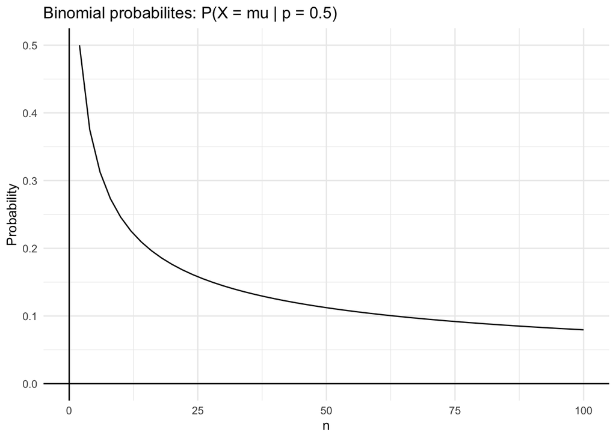

```r
ggplot(prob5, aes(x=n, y=prob)) +
  geom_line() +
  geom_hline(yintercept = 0) +
  geom_vline(xintercept = 0) +
  labs(y = "Probability", title ="Binomial probabilites: P(X = mu | p = 0.5)") +
  theme_minimal()
```

**Part c** Describe the pattern: how does the probability that a random variable is equal to the mean (when the mean is a possible value) change as $n$ increases?

> The probability that X is equal to the mean decreases as n increases, but the rate of decrease lessens.

# Problem 5

Find the probabilities of the area shaded in the graph below for $\text{Normal}(2.8, 6)$.

1. Don’t change the R chunk below

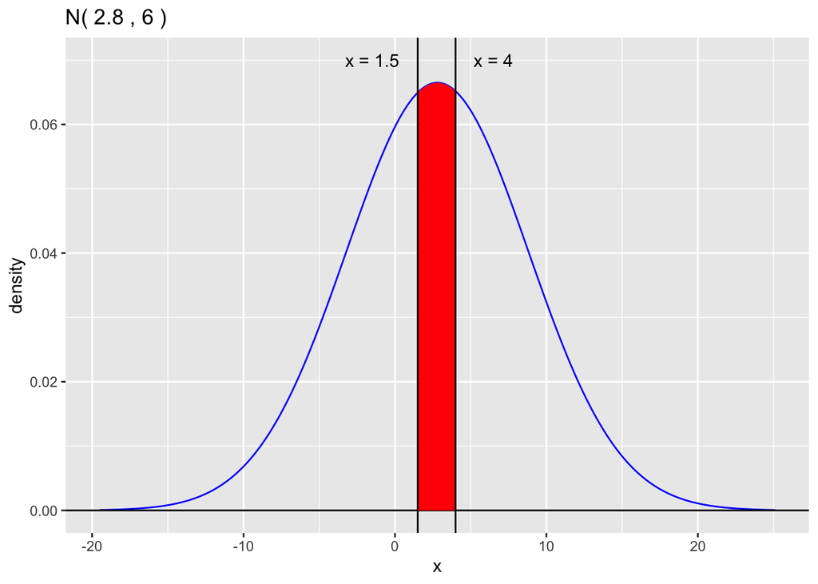

```r
gnorm(2.8, 6) +
  geom_norm_fill(2.8, 6, a = 1.5, b = 4, fill = "red") +
  geom_vline(xintercept = 1.5) +
  geom_vline(xintercept = 4) +
  annotate("text", x = -1.5, y = .07, label = "x = 1.5") +
  annotate("text", x = 6.5, y = .07, label = "x = 4")
```

Solution:

```r
pnorm(4, 2.8, 6) - pnorm(1.5, 2.8, 6)
```

```
## [1] 0.1650256
```

2. Don’t change the R chunk below

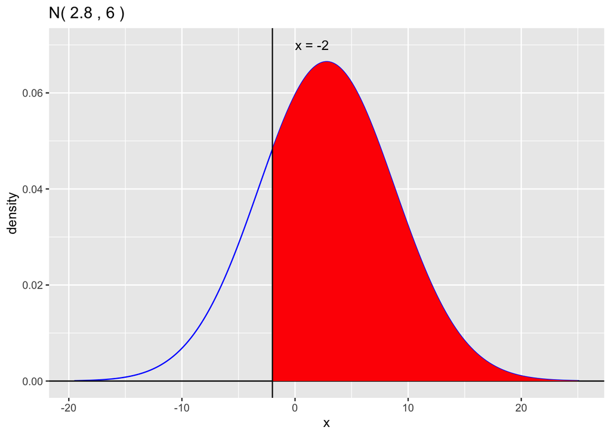

```r
gnorm(2.8, 6) +
  geom_norm_fill(2.8, 6, a = -2, b = 25, fill = "red") +
  geom_vline(xintercept = -2) +
  annotate("text", x = 1.5, y = .07, label = "x = -2")
```

Solution:

```r
pnorm(-2, 2.8, 6, lower.tail = FALSE)
```

```
## [1] 0.7881446
```

4. Don’t change the R chunk below

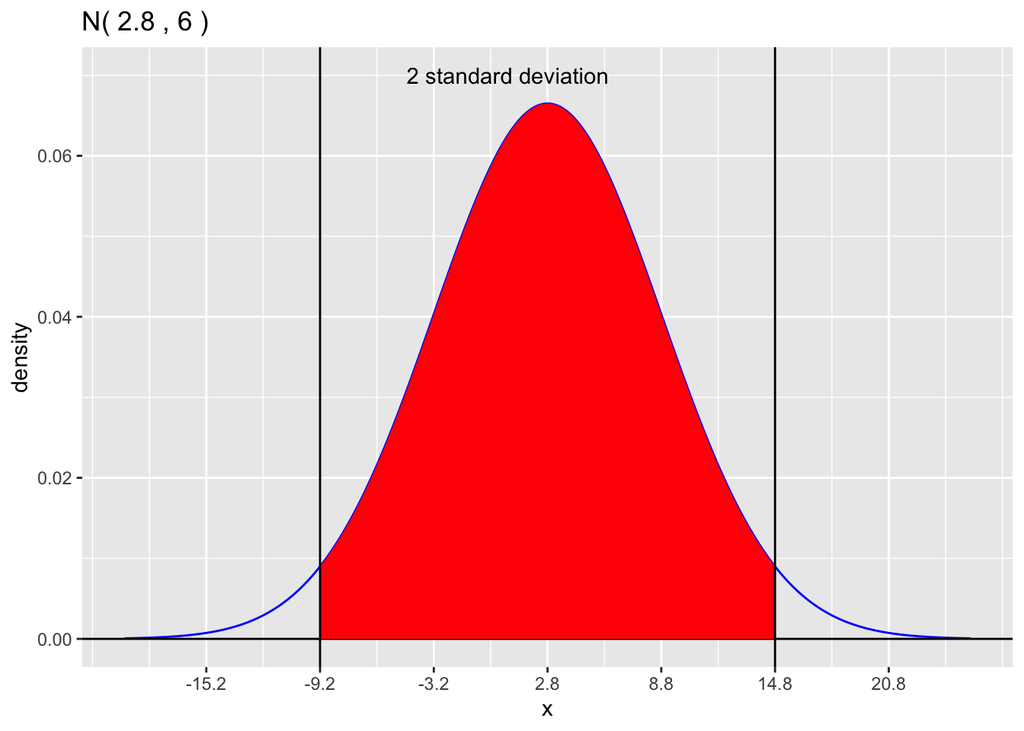

```r
mu = 2.8
sigma = 6
gnorm(2.8, 6) +
  geom_norm_fill(2.8, 6, a = mu-2*sigma, b =  mu+2*sigma, fill = "red") +
  geom_vline(xintercept =  mu-2*sigma) +
  geom_vline(xintercept =  mu+2*sigma) +
  annotate("text", x = 0.7, y = .07, label = "2 standard deviation") +
  scale_x_continuous(breaks = c(mu-3*sigma, mu-2*sigma, mu-sigma, mu, mu+sigma,mu+2*sigma, mu+3*sigma))
```

```r
pnorm(14.8, 2.8, 6) - pnorm(-9.2, 2.8, 6)
```

```
## [1] 0.9544997
```

# Problem 6

The Empirical rule says that about 68% of the data will fall within one standard deviation, about 95% within two standard deviations, and about 99.7% within three standard deviations from the mean. Calculate these probabilities for $\text{Normal}(0,1)$ and print a data set containing all those values.

Solution:

```r
tibble(row = 1:3) %>% mutate("no. of dev apart" = c("1 s.d", "2 s.d", "3 s.d"), prob = c(pnorm(1, 0, 1)-pnorm(-1, 0, 1), pnorm(2, 0, 1)-pnorm(-2, 0, 1), pnorm(3, 0, 1)-pnorm(-3, 0, 1)))
```

```
## # A tibble: 3 × 3
##     row `no. of dev apart`  prob
##   <int> <chr>              <dbl>
## 1     1 1 s.d              0.683
## 2     2 2 s.d              0.954
## 3     3 3 s.d              0.997
```